# Spatial Modeling

#### Motivation

We have studied a variety of data sets thus far that included observations of responses and accompanying predictors (i.e. covariates) for each response. We have ignored the fact that these observations must occur somewhere despite the fact that many, if not all, research problems in environmental and social science are inherently spatial. The usual layout for these data sets is that each row contains a response and predictor variables. Spatial data sets have these of course, but each row also contains geographic coordinates — usually latitude and longitude or, better yet, UTM coordinates, giving each observation a specific location in space.

Why do we care? Remember a fundamental assumption of virtually all statistical modeling is that the residuals are independent and identically distributed:

$$\begin{align}
y_i &= g(\theta, x_i)+\epsilon_{i} \\
\epsilon_{i} &\sim \textrm{normal}(0, \sigma^2)
\end{align}$$

We have some deterministic model $g(\theta, x_{i})$ that predicts an observation $y_i$ with some error $\epsilon_i$. The errors must be independent, which is to say that information about one $\epsilon_{i}$ tells you nothing about another $\epsilon_{i}$. Recall we can combine the likelihoods of individual observations into a total likelihood across an observation set by taking a product of the individual likelihoods, if we can assume independence. The assumption of independence means that the $\boldsymbol{\epsilon}$’s must be independent.

It is often the case that observations that are close together in space are more similar than observations that are farther apart.This is not a problem if our model accounts for this relationship by the clever use of covariates, but sometimes covariates cannot account for all the spatial dependence in the data, leaving $\boldsymbol{\epsilon}$’s that resemble their neighbors. This means that $\boldsymbol{\epsilon}$’s that are close together are conditional, which is to say of course that information about one $\epsilon$ informs us to some degree about its neighbors. Another way to express this conditional relationship is that $\boldsymbol{\epsilon}$’s are *autocorrelated*. It is vital that you understand that this is different from auto correlation in the *data*, which will almost always be present at some scale.

The Bayesian framework does not flinch at autocorrelated $\boldsymbol{\epsilon}$’s. We deal with spatially conditional residuals in precisely the same way we deal with all other unobserved quantities: we model them.

We have learned about two types of spatial data – data like observations of soil moisture or disease prevalence arising from a continuous spatial process and data like average income or political affiliation that reflect an area – a state, county, or precinct. We will focus on continuous spatial data here, but the approach is not dramatically different for areal data.

The best way to learn new modeling skills involves three steps:

1. Understand the math. Understand the math. Understand the math.

2. Simulate data so that you *know* the values of generating, unobserved quantities.

3. Write code to implement the mathematics using the simulated data.

Step 1 was handled in the lecture on spatial modeling and your deep thoughts about the topic. We will go through steps 2–3 in this problem.

#### Preliminaries

Utah has great canyon country, decent breweries in Moab, the Uinta mountains, and some of the driest, deepest powder anywhere. You can get on a bus in downtown Salt Lake and be at the base of Alta in about 45 minutes. It is also the state where Mevin Hooten was on the faculty at Utah State University before he joined us a Colorado State. Mevin developed much of this exercise, explaining why it is about Utah, but I actually prefer the powder explanation. You could easily modify to any state of your choosing, but rectangular ones work better than Massachusetts.

You will need to load the following R libraries for this problem. If they are not installed in R, please install them with `install.packages()`.

```r
suppressMessages(library(gstat))
suppressMessages(library(maps))
suppressMessages(library(mvtnorm))
suppressMessages(library(rjags))
suppressMessages(library(rgdal))
suppressMessages(library(maptools))
set.seed(13)
```

The code below is not needed for the exercise, but the spatially inclined among you may find it useful at some point, so I included it. The code produces an R object `utgrid.locs` that contains the spatially referenced grid of points overlaying Utah. We will use `utgrid.locs` in to simulate data for this lab.

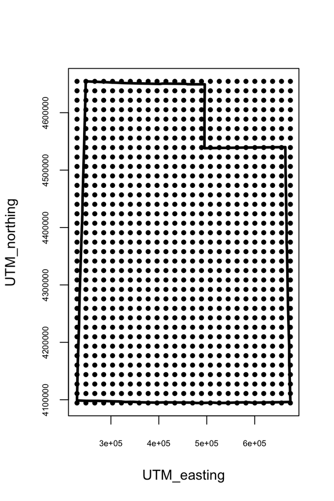

```r
ut.st = map("state", regions = "utah", fill = T, plot = F)
ut.coords = cbind(ut.st$x, ut.st$y)
ut.latlon = SpatialPoints(ut.coords, proj4string = CRS("+proj=longlat +datum=WGS84"))
ut.utm = spTransform(ut.latlon,CRS("+proj=utm +zone=12  +datum=WGS84"))
ut.range = ut.utm@bbox
xg = seq(ut.range[1], ut.range[3],, 25)
yg = seq(ut.range[2], ut.range[4],, 35)
utgrid.locs = as.matrix(expand.grid(xg, yg))
plot(utgrid.locs, pch = 20, xlab = "UTM_easting", ylab = "UTM_northing", cex.axis = .6,
     xlim = c(min(xg), max(xg)), ylim = c(min(yg), max(yg)))
points(ut.utm@coords, type = "l", lwd = 3)
```

#### Simulating data

You should work to understand what is going on from now on, with the exception of some of the plotting, which you can figure out at another time. We start by simulating some data with spatially structured standardized covariates and a response that lacks spatial dependence except the dependence created by the covariates. Study the code below. Especially take note of how the $y$s are simulated.

```r
x = scale(utgrid.locs[, 1]) + scale(utgrid.locs[, 2])
dat = cbind(utgrid.locs, x)
colnames(dat) = c("easting", "northing", "x")
n <- dim(utgrid.locs)[1]
```

Don’t worry about the transformation! - instead focus on the spatial patterning in $x$ when we plot of each of their values on a map using their associated coordinates. It should be obvious that these predictors could give rise to spatially structured data.

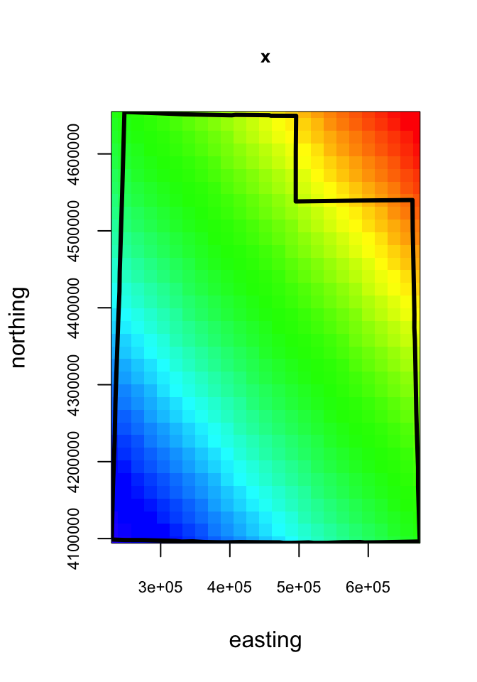

```r
image(matrix(dat[, 3], length(xg), length(yg)), x = xg, y = yg, main = "x",
      col = rev(rainbow(100, start = 0, end = .7)), xlab = "easting", ylab = "northing",
      cex.main = .8, cex.axis = .7, xlim = c(min(xg), max(xg)), ylim = c(min(yg), max(yg)))
points(ut.utm@coords, type = "l", lwd = 3)
```

Next we make an unstructured response variable. To do this, we make a design matrix with 2 columns and 875 rows, where the number of rows corresponds to the number of UTM coordinates. The first columns represents the intercept and is a vector of 1s and the second column is the $x$s.

```r
X = matrix(c(rep(1, n), dat[,3]), n, 2, byrow = FALSE)
```

We define some $\beta$ coefficients and a $\sigma$. Then we simulate a vector of responses using a normal distribution. This is the same as making 875 draws from `rnorm`, one for each grid point, where $\mu$ is a vector of means computed as the product of the design matrix $X$ and the vector $\beta$:

$$\begin{eqnarray}
y_{i} &\sim& \textrm{normal}(\mu_{i}, \sigma^{2})\\
\mu_{i} & = & \boldsymbol{X}\times\boldsymbol{\beta}
\end{eqnarray}$$

```r
beta = c(1, -2)
sigma = .5
y = rnorm(n, X%*%beta, sigma)
dat = as.data.frame(cbind(y, dat))
```

```r
head(dat)
```

```
##          y  easting northing         x
## 1 7.968040 229327.6  4094423 -3.345438
## 2 7.273549 247874.3  4094423 -3.206842
## 3 8.024075 266421.0  4094423 -3.068247
## 4 6.952962 284967.7  4094423 -2.929651
## 5 7.153373 303514.3  4094423 -2.791055
## 6 6.512681 322061.0  4094423 -2.652459
```

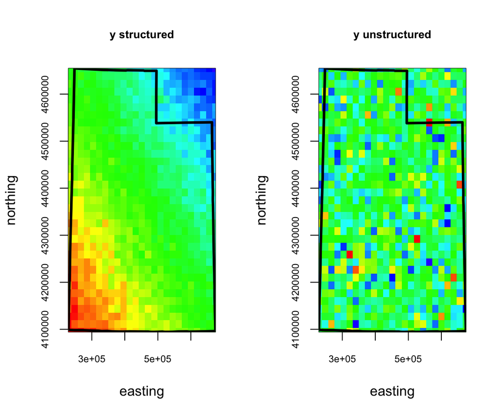

```r
par(mfrow = c(1, 2))
image(matrix(dat$y, length(xg), length(yg)), x = xg, y = yg, main = "y structured",
      col = rev(rainbow(100, start = 0, end = .7)), xlab = "easting", ylab = "northing",
      cex.main = .8, cex.axis = .7, xlim = c(min(xg), max(xg)), ylim = c(min(yg), max(yg)))
points(ut.utm@coords, type = "l", lwd = 3)
image(matrix(rnorm(n, mean = 1.57, sd = 1.82), length(xg), length(yg)), x = xg, y = yg, main="y unstructured",
      col = rev(rainbow(100, start = 0, end = .7)), xlab = "easting", ylab = "northing",
      cex.main = .8, cex.axis = .7, xlim = c(min(xg), max(xg)), ylim = c(min(yg), max(yg)))
points(ut.utm@coords, type = "l", lwd = 3)
```

#### Aspatial model

Here is the joint distribution using the multivariate normal:

$$\begin{align}
\big[\beta_{1}, \beta_{2}, \sigma \mid \mathbf{y}\big] & \propto \textrm{multivariate normal}\big(\mathbf{y} \mid \boldsymbol{\mu},\sigma^{2}I\big) \textrm{normal}\big(\beta_{1} \mid 0, 1E5 \big) \textrm{normal}\big(\beta_{2} \mid 0, 1E5 \big) \textrm{uniform}\big(\sigma \mid 0, 10\big)\\
\boldsymbol{\mu}&=\mathbf{X}\boldsymbol{\beta}
\end{align}$$

The second argument to the multivariate normal is a variance covariance matrix, which in this case is simply a matrix with $\sigma^2$ on the diagonal and zeros elsewhere:

$$\sigma^{2}I = \sigma^2
\begin{bmatrix}
1 & 0 & 0 & \dots & 0 \\
0 & 1 & 0 & \dots & 0 \\
\vdots & \vdots & \vdots & \ddots & \vdots \\
0 & 0 & 0 & \dots & 1
\end{bmatrix}_{\,\,875\times 875} =
\begin{bmatrix}
\sigma^{2} & 0 & 0 & \dots & 0 \\
0 & \sigma^{2} & 0 & \dots & 0 \\
\vdots & \vdots & \vdots & \ddots & \vdots \\
0 & 0 & 0 & \dots & \sigma^{2}
\end{bmatrix}_{\,\,875 \times 875}$$

1. How did I determine the dimensions of the identity matrix?

Spatial models take a long time to run so a useful way to work is to subset the data to reduce the number of points and use a small number of iterations until you get some reasonable if not perfect results. Then increase the size of the data set and the number of iterations. The code below will be helpful in doing that. Ir starts by keeping 20% of the data and uses a small number of iterations for a single chain. We plot the predictor and label all the data points we selected for our model with black circles. We do this simply to make sure that our random draw of samples has pretty even spatial coverage prior to fitting.

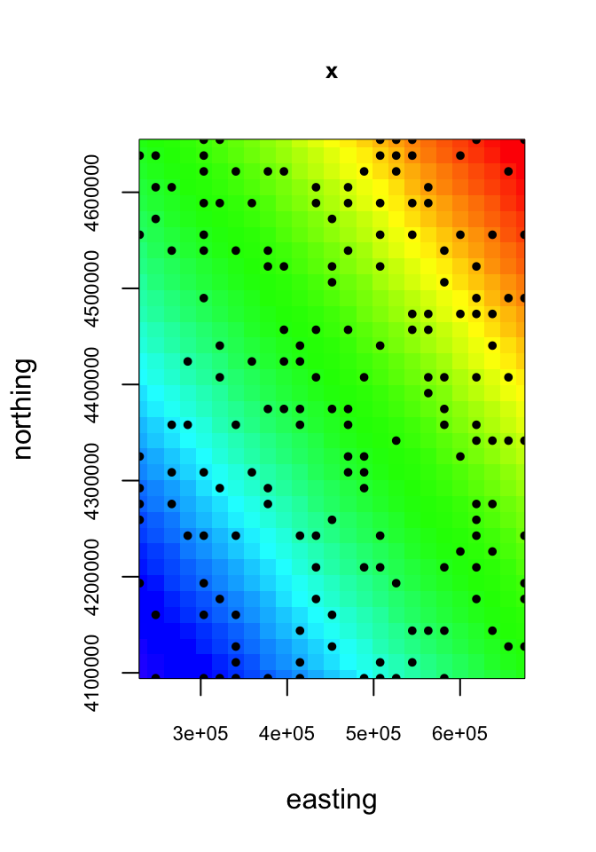

```r
n.adapt = 500
n.update = 1000
n.iter = 1000
k = sort(sample(1:n, round(0.2 * n)))

inits = list(
  list(
    beta = c(.8, -.8),
    sigma = .02
  )
)

data = list(
  y = as.double(dat$y[k]),
  X = X[k,],
  k = length(k)
)

image(matrix(dat[, 4], length(xg), length(yg)), x = xg, y = yg, main = "x",
      col = rev(rainbow(100, start = 0, end = .7)), xlab = "easting", ylab = "northing",
      cex.main = .8, cex.axis = .7, xlim = c(min(xg), max(xg)), ylim = c(min(yg), max(yg)))
points(utgrid.locs[k,], pch = 20, cex = .8)
```

2. Time to write the model using the normal distribution. Use the priors we provide above to save time and remember it is critical that your code contains a derived quantity for the residuals, i.e., $\epsilon_i=y_i-\mu_i$. Include code for a posterior predictive check for the coefficient of variation.

3. Run the model in JAGS with a single chain. How would we assess convergence with just one chain?

4. Determine if the model recovers the generating values for $\boldsymbol{\beta}$ and $\sigma$. If they are not spot on what do you think is happening?

5. Plot the residuals on a map of Utah. OK, don’t panic. Review page 29 of the JAGS Primer to see how to capture the means of posteriors from a coda sample into a vector. Do this for the $\epsilon$s. Then merge these epsilon values with the correct spatial coordinates from the `dat` data frame before plotting. I suggest making a new variable in `dat` that is NA where there is no corresponding epsilon. Then use the same image code above to plot these residuals on a map of Utah.

7. Plot the median and 95% credible intervals for the predicted response $y$ as a function of the predictor $x$. Examine the posterior predictive check. Does the model fit the data well?

8. Re code the model using a multivariate normal and repeat this exercise. Compare your results. Notice, you will need to give JAGS an identity matrix $I$ as data this time.

#### Aspatial model redux

We now want to add spatial structure into that is not accounted for by the covariates. Here again is the joint distribution using the multivariate normal:

$$\begin{align}
\big[\beta_{1}, \beta_{2}, \sigma, \varsigma, \phi \mid \mathbf{y}\big] & \propto \textrm{multivariate normal}\big(\mathbf{y} \mid \boldsymbol{\mu},\boldsymbol{\Sigma} + \sigma^{2}I\big) \textrm{normal}\big(\beta_{1} \mid 0, 1E5 \big) \textrm{normal}\big(\beta_{2} \mid 0, 1E5 \big)\\
& \times \textrm{uniform}\big(\sigma \mid 0, 10\big)\textrm{uniform}\big(\varsigma \mid 0, 10\big)\textrm{uniform}\big(\phi \mid 20000, 80000\big)\\
\boldsymbol{\mu}&=\mathbf{X}\boldsymbol{\beta}
\end{align}$$

except this time the variance covariance matrix now has two sources of error, the original uncorrelated error captured by $\sigma^2I$ and the new exponentially correlated errors from $\boldsymbol{\Sigma}$ such that:

$$\boldsymbol{\Sigma} = \varsigma^{2}\textrm{exp}\Big(\frac{-d_{i,j}}{\phi}\Big) =
\begin{bmatrix}
\varsigma^{2} & \varsigma^{2}e^{-\frac{d_{1,2}}{\phi}} & \varsigma^{2}e^{-\frac{d_{1,3}}{\phi}} & \dots & \varsigma^{2}e^{-\frac{d_{1,875}}{\phi}} \\
\varsigma^{2}e^{-\frac{d_{2,1}}{\phi}} & \varsigma^{2} & \varsigma^{2}e^{-\frac{d_{2,3}}{\phi}} & \dots & \varsigma^{2}e^{-\frac{d_{2,875}}{\phi}} \\
\vdots & \vdots & \vdots & \ddots & \vdots \\
\varsigma^{2}e^{-\frac{d_{875,1}}{\phi}} & \varsigma^{2}e^{-\frac{d_{875,2}}{\phi}} & \varsigma^{2}e^{-\frac{d_{875,3}}{\phi}} & \dots & \varsigma^{2}
\end{bmatrix}_{\,\,875\times 875}$$

1. Study the code below that simulates data using the above model until you understand it. You may need to refer to the lecture notes. We get a vector of new $\epsilon$s using `rmvnorm`, which returns a single vector of length 875 centered on 0. `Sigma` is calculated above to reflect spatial autocorelation. Now we create spatially structured data by adding these new spatially structured random variables to the unstructured `y`s.

```r
D <- as.matrix(dist(utgrid.locs))
sigma_structured <- 2
phi <- 50000
Sigma <- sigma_structured * exp(-D / phi)
epsilon_spatial <- as.vector(rmvnorm(1, matrix(0, n, 1), Sigma, method = "chol"))
dat$y_structured <- dat$y + epsilon_spatial
```

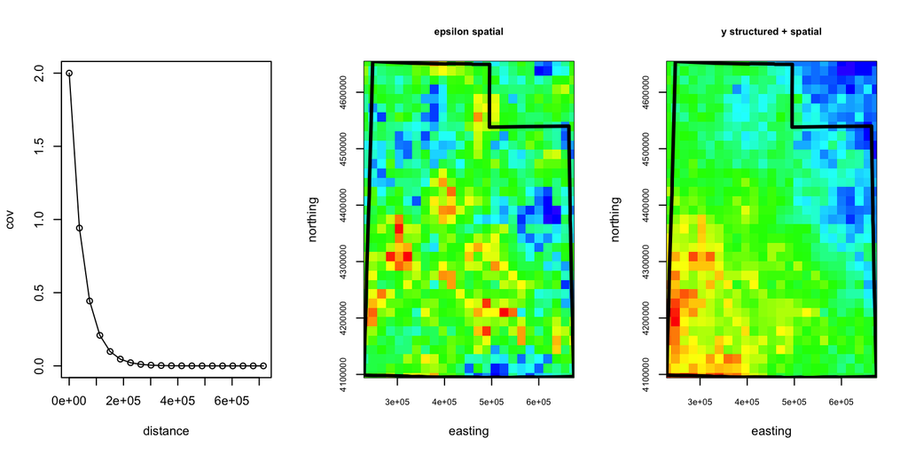

```r
par(mfrow = c(1, 3))
plot(seq(0, max(D),, 20), sigma_structured * exp(-seq(0, max(D),, 20) / phi), type = "o",
     ylab = "cov", xlab = "distance")
image(matrix(epsilon_spatial, length(xg), length(yg)), x = xg, y = yg, main = "epsilon spatial",
      col = rev(rainbow(100, start = 0, end = .7)), xlab = "easting", ylab = "northing",
      cex.main = .8, cex.axis = .7, xlim = c(min(xg), max(xg)), ylim = c(min(yg), max(yg)))
points(ut.utm@coords, type = "l", lwd = 3)
image(matrix(dat$y_structured, length(xg), length(yg)), x = xg, y = yg, main = "y structured + spatial",
      col = rev(rainbow(100, start = 0, end = .7)), xlab = "easting", ylab = "northing",
      cex.main = .8, cex.axis = .7, xlim = c(min(xg), max(xg)), ylim = c(min(yg), max(yg)))
points(ut.utm@coords, type = "l", lwd = 3)
```

2. Run the model in JAGS with a single chain and assess convergence.

3. Determine if the model recovers the generating values for $\boldsymbol{\beta}$ and $\sigma$.

4. Plot the residuals on a map of Utah. Compare these to the aspatial residuals from the previous exercise.

5. Assess the spatial independence of the residual means using a variogram. Compare these to the aspatial residuals from the previous exercise.

6. Plot the median and 95% credible intervals for the predicted response $y$ as a function of the predictor $x$. Examine the posterior predictive check. Does the model fit the data well? Compare these results to the aspatial model fit to the aspatial data.

#### Spatial model

Modify the aspatial model to account for spatial dependence in the residuals. How many new parameters must be predicted? Again, we give you the data and the inits to accelerate things.

```r
inits = list(
  list(
    beta = c(.8, -.8),
    sigma = c(.02, 1),
    phi = 50000)
)

data = list(
  y = as.double(dat$y_structured[k]),
  X = X[k,],
  D = matrix(D[k, k], nrow = length(k), ncol = length(k)),
  y.I = diag(length(k))
)
```

1. Time to write the spatial model. Use the priors we provide above to save time and remember it is critical that your code contains a derived quantity for the residuals, i.e., $\epsilon_i=y_i-\mu_i$. Again, include code for a posterior predictive check for the coefficient of variation.

2. Run the model in JAGS with a single chain and assess convergence.

3. Determine if the model recovers the generating values for $\boldsymbol{\beta}$, $\sigma$, $\varsigma$, and $\phi$.

4. Plot the residuals on a map of Utah. Compare these to the residuals from the other models.

5. Assess the spatial independence of the residual means using a variogram. Compare these to the residuals from the other models.

6. Plot the median and 95% credible intervals for the predicted response $y$ as a function of the predictor $x$. Examine the posterior predictive check. Does the model fit the data well? Compare these results to the other models.